# Warm-up 4

# Import the Data in R

```r
getwd()
```

```
## [1] "C:/Users/nabki/Desktop/Stat 133"
```

```r
setwd("C:/Users/nabki/Desktop/Stat 133")

library(readr)

nba <- read_csv("nba2018.csv",col_names = TRUE,
col_types =  list(
 player = 'c',
team = 'c',
height = 'c',
birth_date = 'c',
country = 'c', experience = 'c', college = 'c',
                  position = col_factor(levels = c('C','PF','PG','SF','SG')),

                  salary = 'd', field_goals_perc = 'd', points3_perc = 'd', points2_perc = 'd',
 points1_perc = 'd',
 effective_field_goal_perc = 'd',
                   number = 'i', weight = 'i', rank = 'i', age = 'i',
                  games = 'i',
                  games_started = 'i',
                  minutes = 'i',
                  field_goals = 'i',
                  field_goals_atts = 'i',
                  points3 = 'i', points3_atts = 'i', points2 = 'i',
                  points2_atts = 'i',
                  points1 = 'i',
                  points1_atts = 'i',
                  off_rebounds = 'i',
                  def_rebounds = 'i',
                  assists = 'i', steals = 'i',
                  blocks = 'i',
                  turnovers = 'i', fouls = 'i',
                  points = 'i' ))
str(nba)
```

```
## Classes 'tbl_df', 'tbl' and 'data.frame':    477 obs. of  38 variables:
##  $ player                   : chr  "Al Horford" "Amir Johnson" "Avery Bradley" "Demetrius Jackson" ...
##  $ number                   : int  42 90 0 9 30 4 99 13 7 8 ...
##  $ team                     : chr  "BOS" "BOS" "BOS" "BOS" ...
##  $ position                 : Factor w/ 5 levels "C","PF","PG",..: 1 2 5 3 4 3 4 5 4 2 ...
##  $ height                   : chr  "6-10" "6-9" "6-2" "6-1" ...
##  $ weight                   : int  245 240 180 201 205 185 235 215 225 231 ...
##  $ birth_date               : chr  "June 3, 1986" "May 1, 1987" "November 26, 1990" "September 7, 1994" ...
##  $ country                  : chr  "do" "us" "us" "us" ...
##  $ experience               : chr  "9" "11" "6" "R" ...
##  $ college                  : chr  "University of Florida" NA "University of Texas at Austin" "University of Notre Dame" ...
##  $ salary                   : num  26540100 12000000 8269663 1450000 1410598 ...
##  $ rank                     : int  4 6 5 15 11 1 3 13 8 10 ...
##  $ age                      : int  30 29 26 22 31 27 26 21 20 29 ...
##  $ games                    : int  68 80 55 5 47 76 72 29 78 78 ...
##  $ games_started            : int  68 77 55 0 0 76 72 0 20 6 ...
##  $ minutes                  : int  2193 1608 1835 17 538 2569 2335 220 1341 1232 ...
##  $ field_goals              : int  379 213 359 3 95 682 333 25 192 114 ...
##  $ field_goals_atts         : int  801 370 775 4 232 1473 720 58 423 262 ...
##  $ field_goals_perc         : num  0.473 0.576 0.463 0.75 0.409 0.463 0.463 0.431 0.454 0.435 ...
##  $ points3                  : int  86 27 108 1 39 245 157 12 46 45 ...
##  $ points3_atts             : int  242 66 277 1 111 646 394 35 135 130 ...
##  $ points3_perc             : num  0.355 0.409 0.39 1 0.351 0.379 0.398 0.343 0.341 0.346 ...
##  $ points2                  : int  293 186 251 2 56 437 176 13 146 69 ...
##  $ points2_atts             : int  559 304 498 3 121 827 326 23 288 132 ...
##  $ points2_perc             : num  0.524 0.612 0.504 0.667 0.463 0.528 0.54 0.565 0.507 0.523 ...
##  $ effective_field_goal_perc: num  0.527 0.612 0.533 0.875 0.494 0.546 0.572 0.534 0.508 0.521 ...
##  $ points1                  : int  108 67 68 3 33 590 176 6 85 26 ...
##  $ points1_atts             : int  135 100 93 6 41 649 217 9 124 37 ...
##  $ points1_perc             : num  0.8 0.67 0.731 0.5 0.805 0.909 0.811 0.667 0.685 0.703 ...
##  $ off_rebounds             : int  95 118 65 2 16 43 48 6 45 59 ...
##  $ def_rebounds             : int  370 248 269 2 68 162 367 20 175 213 ...
##  $ total_rebounds           : int  465 366 334 4 84 205 415 26 220 272 ...
##  $ assists                  : int  337 140 122 3 33 448 155 4 64 71 ...
##  $ steals                   : int  52 51 68 0 9 70 73 10 35 25 ...
##  $ blocks                   : int  86 62 11 0 7 13 23 2 18 17 ...
##  $ turnovers                : int  115 77 88 0 25 210 80 4 68 39 ...
##  $ fouls                    : int  138 211 141 0 48 167 161 15 142 122 ...
##  $ points                   : int  952 520 894 10 262 2199 999 68 515 299 ...
##  - attr(*, "problems")=Classes 'tbl_df', 'tbl' and 'data.frame': 1 obs. of  5 variables:
```

[output cut: 74 more lines]

[output not shown]

# Right after importing data

```r
nba$experience[nba$experience == "R"] = 0

exp <- as.integer(nba$experience)

summary(exp)
```

```
##    Min. 1st Qu.  Median    Mean 3rd Qu.    Max.
##   0.000   1.000   4.000   4.662   7.000  18.000
```

```r
salary <- nba$salary/1000000
summary(salary)
```

```
##      Min.   1st Qu.    Median      Mean   3rd Qu.      Max.
##  0.005145  1.050961  3.000000  5.804697  8.269663 30.963450
```

```r
levels(nba$position) <-  c("center", "power_fwd", "point_guard", "small_fwd", "shoot_guard")
table(nba$position)
```

```
##
##      center   power_fwd point_guard   small_fwd shoot_guard
##          97          98          96          84         102
```

# A bit of subscripting

```r
#How many players went to UCLA?
NROW(nba$player[which(nba$college == "University of California, Los Angeles")])
```

```
## [1] 14
```

```r
#How many players went to Cal?
NROW(nba$player[which(nba$college == "University of California, Berkeley")])
```

```
## [1] 0
```

```r
#What's the largest weight?
max <- max(nba$weight)
max
```

```
## [1] 290
```

```r
#Who are the players with the largest weights?
nba$player[nba$weight == max]
```

```
## [1] "Boban Marjanovic"
```

```r
#What' the overall average weight?
mean(nba$weight)
```

```
## [1] 219.9119
```

```r
#What is the median salary of all players?
median(nba$salary)
```

```
## [1] 3e+06
```

```r
#What is the median salary of the players with 10 years of experience or more?
median(nba$salary[nba$experience >= 10])
```

```
## [1] 5409119
```

```r
#What is the median salary of Shooting Guards (SG) and the Point Guards (PG)
median(nba$salary[nba$position == 'shoot_guard' | nba$position == 'point_guard'])
```

```
## [1] 2789698
```

```r
#What is the median salary of Power Forwards (PF), 30 years or older, weighing 240 pounds or more?
median(nba$salary[nba$position == 'power_fwd' & nba$age >= 30 & nba$weight >= 240])
```

```
## [1] 8e+06
```

# Performance of players

```r
nba$missed_field_goals <- nba$field_goals_atts - nba$field_goals

nba$missed_free_throws <- nba$points1_atts - nba$points1

nba$rebounds <- nba$total_rebounds

nba$mins_game <- nba$minutes / nba$games

nba$efficiency <-  (nba$points + nba$total_rebounds + nba$assists + nba$steals +

                      nba$blocks - nba$missed_field_goals - nba$missed_free_throws - nba$turnovers) / nba$games

summary(nba$efficiency)
```

```
##    Min. 1st Qu.  Median    Mean 3rd Qu.    Max.
## -0.6667  5.0000  8.3472  9.5788 12.6066 33.8272
```

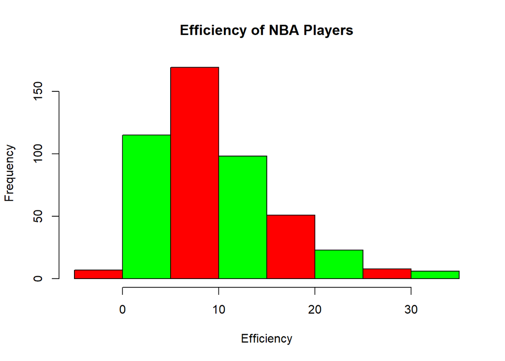

```r
hist(nba$efficiency, col = c('red','green'), xlab = "Efficiency", main = "Efficiency of NBA Players")
```

```r
top_10 <- subset(nba[order(nba$efficiency, decreasing = TRUE),], select = c(player, team, salary, efficiency))

top_10
```

```
## # A tibble: 477 x 4
##    player                team    salary efficiency
##    <chr>                 <chr>    <dbl>      <dbl>
##  1 Russell Westbrook     OKC   26540100       33.8
##  2 James Harden          HOU   26540100       32.4
##  3 Anthony Davis         NOP   22116750       31.1
##  4 LeBron James          CLE   30963450       31.0
##  5 Karl-Anthony Towns    MIN    5960160       30.3
##  6 Kevin Durant          GSW   26540100       30.2
##  7 Giannis Antetokounmpo MIL    2995421       28.4
##  8 DeMarcus Cousins      NOP   16957900       27.9
##  9 Jimmy Butler          CHI   17552209       25.6
## 10 Hassan Whiteside      MIA   22116750       25.4
## # ... with 467 more rows
```

```r
top_10$player[top_10$efficiency < 0]
```

```
## [1] "Gary Neal"       "Axel Toupane"    "Patricio Garino" "Ben Bentil"
```

# Comments and Reflections

**How much time did it take to complete this HW?** It took me around 4 days to do this HW

**What things were hard, even though you saw them in class/lab?** Using the readr function to open the csv file was very difficult.

**What was easy(-ish) even though we haven’t done it in class/lab?** It was all pretty challenging

**Did you need help to complete the assignment? If so, what kind of help?** Yes I worked with some friends

**What was the most time consuming part?** Opening the file and setting the directory because I could not understand why it was not working for me

**Was there anything that you did not understand? or fully grasped?** I do not really understand relabeling the vectors in a column

**Was there anything frustrating in particular?** Not knowing how to set things up from a bash command